# 02-prac-norms-svd

**Задача 1**  
Пусть $\Vert x\Vert$ - векторная норма в $\mathbb{C}^n$, $A \in \mathbb{C}^n$ - невырожденная матрица. Докажите, что $\Vert x\Vert_{*} = \Vert A x\Vert$ также является векторной нормой.

**Задача 2**  
Проверьте, является ли выражение $\min (|x_1| + 5|x_2|, 5 |x_1| + |x_2|)$ нормой вектора в $\mathbb{R}^2$?

**Задача 3**  
Выведите выражения для $||A||_1$ и $||A||_\infty$ через элементы матриц.  
*Подсказка: используя определение операторной нормы, получите оценку сверху для отношения, по которому берётся $\max$, а потом подберите элемент $x$ на котором оценка достигается.*

**Задача 4**
Докажите, что $$ ||A^T A||_1 \le ||A||_1 \; ||A||_\infty $$

**Задача 5**  
Приведите пример векторной нормы в пространстве матриц одинакового размера, которая не является матричной нормой.

**Задача 6**  
Докажите, что для любой эрмитовой матрицы $H$ матрица $Q = (I - i H)^{-1} (I + i H)$ будет унитарной.

**Задача 7**  
Используя сингулярное разложение, докажите, что $\Vert A \Vert_2 = \sigma_{max}$.

**Задача 8**  
$A = U \Sigma V^T$ - сингулярное разложение невырожденной матрицы $A \in \mathbb{R}^{n \times n}$. Выпишите сингулярное разложение $A^{-1}$.

**Задача 9**

1. Изучите код в следующем окне
2. Создайте в цикле несколько случайных матриц, напечатайте нормы 1,2 и $\infty$ для этих матриц, а также напечатайте максимальный модуль собственного числа (спектральный радиус) созданных матриц. Как он соотносится с нормами матриц?  
   Докажите, что так будет всегда.

```python
%matplotlib inline
import numpy as np

n = 10
a1 = np.array([0,1,2,3]) # так можно создать массив по списку
print('type(a1[0]) = ', type(a1[0])) # Обратите внимание на тип
a2 = np.array([0.0,1,2,3]) # Один из элементов - float
print('type(a2[0]) = ', type(a2[0])) # Обратите внимание на тип

a3 = np.zeros((10)) # np.zeros() и np.ones() по умолчанию имеют тип float64
print('type(a3[0]) = ', type(a3[0])) # Обратите внимание на тип

A = np.zeros((3,3)) # Так можно создать 2D массив из нулей
A = np.random.rand(3,3) # Случайный массив
print('A = \n', A)

A2 = np.array([[1,2,3], [4,5,6]])
print('A2 = \n', A2)
# Второй столбец матрицы A2
print('A2[:,1] = ', A2[:,1])

x = np.ones(3)
b = A @ x # @ - матрично-векторное умножение
b = np.dot(A,x) # матрично-векторное умножение
y = np.linalg.solve(A,b) # решаем линейную систему
print('x - y = ', x-y)

l = np.linalg.eigvals(A) # Вычисляются собственные числа
print('l = ', l)
A_1 = np.linalg.norm(A,1)
print('||A||_1 = ', A_1)
# ?np.linalg.solve # так можно вывести документацию для функции
Ainv = np.linalg.inv(A) # Обратная матрица
AT = A.T # Транспонирование
```

```
type(a1[0]) =  <class 'numpy.int32'>
type(a2[0]) =  <class 'numpy.float64'>
type(a3[0]) =  <class 'numpy.float64'>
A =
 [[0.81614147 0.02438865 0.55658806]
 [0.91808722 0.59803659 0.10805558]
 [0.30096964 0.98200693 0.212489  ]]
A2 =
 [[1 2 3]
 [4 5 6]]
A2[:,1] =  [2 5]
x - y =  [ 1.11022302e-16 -2.22044605e-16 -2.22044605e-16]
l =  [1.48311637+0.j         0.07177535+0.52393445j 0.07177535-0.52393445j]
||A||_1 =  2.035198335973652
```

**Задача 10**

Для любой матрицы $A \in \mathbb{C}^{m \times n}$ введем понятие *псевдо-обратной матрицы* $A^+$. Псевдо-обратная матрица должна удовлетворять следующим условиям:

1. $A A^+ A = A$
2. $A^+ A A^+ = A^+$
3. $(A A^+)^* = A A^+$
4. $(A^+ A)^* = A^+ A$

Выведите формулу для $A^+$ через факторы сингулярного разложения матрицы $A$

**Задача 11**
Докажите, что $$ \Vert A \Vert_F = \sqrt{trace(A^* A)} = \sqrt{\sum_{k=1}^{\min\{m,n\}} \sigma_k^2(A)} $$

```
number of images =  1288
```

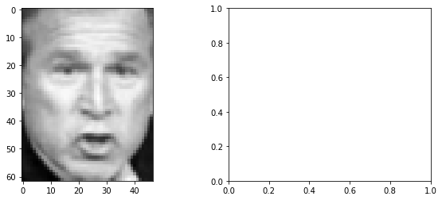

```python
from sklearn.datasets import fetch_lfw_people
from matplotlib import pyplot as plt

# Реализуйте методы класса
class My_PCA:
    def __init__(self, A, r):
        pass

    def forward_map(self, x):
        pass

    def backward_map(self, y):
        pass


# Скачивается несколько минут, запустите заранее!
# Если будут проблемы со скачиванием на комп в аудитории, то попробуйте в Google Colab
lfw_people = fetch_lfw_people(min_faces_per_person=70)

print('number of images = ', len(lfw_people['data']))

# размер картинки
im_shape = (62, 47)

image = lfw_people['data'][20]


image = np.reshape(image, im_shape)
fig, (ax1, ax2) = plt.subplots(1, 2, figsize = (10, 4))
ax1.imshow(image, cmap='gray')

# TODO: add your PCA and plot the compressed picture in ax2
```

**Задача 13 (1 балл)**  
Вычислите приближенно интеграл от функции $f(x,y)$ по прямоугольнику $P = [x_l,x_r]\times[y_l,y_r]$ с помощью SVD. Используйте заготовку кода в следующем окне.

1. Интеграл примерно равен $$\iint_{P} f(x,y)\; dx \, dy \approx \sum_{i,j} f(x_i,y_j) dx dy$$ где $(x_i,y_j)$ - **центры** прямоугольников со сторонами $dx,dy$, на которые разбита область
2. Создайте 2D массив (матрицу) $A$, заполненную значениями функции в этих точках
3. Найдите "обрезанное" SVD матрицы $A$ до заданной точности $tol \approx 10^{-3}$ или до заданного ранга $r$
4. Вычислите интеграл как $dx dy\sum_{i,j} A_r(i,j)$, но не вычисляя элементы матрицы $A_r$, а используя матрицы из "обрезанного" SVD (*используйте формулу для элементов $A_r(i,j)$ через элементы матриц $U,V$, просуммируйте по всем $i,j$, упростите полученное выражение*)
5. Придумайте функцию, для которой интеграл можно вычислить аналитически, постройте график зависимости ошибки в значении интеграла от ранга $r$ приближенной матрицы в логарифмической шкале.

```python
%matplotlib inline
import numpy as np
from matplotlib import pyplot as plt

A = np.random.rand(6,3)
u, s, v = np.linalg.svd(A) # Так вычисляется SVD, V - это V^* в наших обозначениях
print('Shapes:', u.shape, s.shape, v.shape) # s - не матрица, а вектор!
# Так можно построить декартову сетку:
tx = np.linspace(0, 1, 3) # Узлы по x
ty = np.linspace(0, 1, 6) # узлы по y
X, Y = np.meshgrid(tx, ty) # X,Y - 2D массивы
print(X)
print(Y)
f = np.sin(X**2 + Y**2) # Массив значений функции на сетке
```

```
Shapes: (6, 6) (3,) (3, 3)
[[0.  0.5 1. ]
 [0.  0.5 1. ]
 [0.  0.5 1. ]
 [0.  0.5 1. ]
 [0.  0.5 1. ]
 [0.  0.5 1. ]]
[[0.  0.  0. ]
 [0.2 0.2 0.2]
 [0.4 0.4 0.4]
 [0.6 0.6 0.6]
 [0.8 0.8 0.8]
 [1.  1.  1. ]]
```